# ExtraaLearn Project

## Context

The EdTech industry has been surging in the past decade immensely, and according to a forecast, the Online Education market would be worth $286.62bn by 2023 with a compound annual growth rate (CAGR) of 10.26% from 2018 to 2023. The modern era of online education has enforced a lot in its growth and expansion beyond any limit. Due to having many dominant features like ease of information sharing, personalized learning experience, transparency of assessment, etc, it is now preferable to traditional education.

In the present scenario due to the Covid-19, the online education sector has witnessed rapid growth and is attracting a lot of new customers. Due to this rapid growth, many new companies have emerged in this industry. With the availability and ease of use of digital marketing resources, companies can reach out to a wider audience with their offerings. The customers who show interest in these offerings are termed as leads. There are various sources of obtaining leads for Edtech companies, like

- The customer interacts with the marketing front on social media or other online platforms.
- The customer browses the website/app and downloads the brochure
- The customer connects through emails for more information.

The company then nurtures these leads and tries to convert them to paid customers. For this, the representative from the organization connects with the lead on call or through email to share further details.

## Objective

ExtraaLearn is an initial stage startup that offers programs on cutting-edge technologies to students and professionals to help them upskill/reskill. With a large number of leads being generated on a regular basis, one of the issues faced by ExtraaLearn is to identify which of the leads are more likely to convert so that they can allocate resources accordingly. You, as a data scientist at ExtraaLearn, have been provided the leads data to:

- Analyze and build an ML model to help identify which leads are more likely to convert to paid customers,
- Find the factors driving the lead conversion process
- Create a profile of the leads which are likely to convert

## Data Description

The data contains the different attributes of leads and their interaction details with ExtraaLearn. The detailed data dictionary is given below.

**Data Dictionary**

- ID: ID of the lead
- age: Age of the lead
- current_occupation: Current occupation of the lead. Values include 'Professional','Unemployed',and 'Student'
- first_interaction: How did the lead first interacted with ExtraaLearn. Values include 'Website', 'Mobile App'
- profile_completed: What percentage of profile has been filled by the lead on the website/mobile app. Values include Low - (0-50%), Medium - (50-75%), High (75-100%)
- website_visits: How many times has a lead visited the website
- time_spent_on_website: Total time spent on the website
- page_views_per_visit: Average number of pages on the website viewed during the visits.
- last_activity: Last interaction between the lead and ExtraaLearn.
  - Email Activity: Seeking for details about program through email, Representative shared information with lead like brochure of program , etc
  - Phone Activity: Had a Phone Conversation with representative, Had conversation over SMS with representative, etc
  - Website Activity: Interacted on live chat with representative, Updated profile on website, etc
- print_media_type1: Flag indicating whether the lead had seen the ad of ExtraaLearn in the Newspaper.
- print_media_type2: Flag indicating whether the lead had seen the ad of ExtraaLearn in the Magazine.
- digital_media: Flag indicating whether the lead had seen the ad of ExtraaLearn on the digital platforms.
- educational_channels: Flag indicating whether the lead had heard about ExtraaLearn in the education channels like online forums, discussion threads, educational websites, etc.
- referral: Flag indicating whether the lead had heard about ExtraaLearn through reference.
- status: Flag indicating whether the lead was converted to a paid customer or not.

## Importing necessary libraries and data

```python
import pandas as pd
import numpy as np
import matplotlib.pyplot as plt
import seaborn as sns

import warnings
warnings.filterwarnings("ignore")

# Removes the limit for the number of displayed columns
pd.set_option("display.max_columns", None)

# Sets the limit for the number of displayed rows
pd.set_option("display.max_rows", 200)

# To build models for prediction
from sklearn.model_selection import train_test_split, cross_val_score, KFold
from sklearn.linear_model import LinearRegression, Ridge, Lasso, ElasticNet
from sklearn.tree import DecisionTreeRegressor
from sklearn.ensemble import RandomForestRegressor,BaggingRegressor
from sklearn.preprocessing import StandardScaler
from sklearn.decomposition import PCA
from sklearn.cluster import DBSCAN
from sklearn.manifold import TSNE
from sklearn.neighbors import NearestNeighbors

# To encode categorical variables
from sklearn.preprocessing import LabelEncoder

# For tuning the model
from sklearn.model_selection import GridSearchCV

# To check model performance
from sklearn.metrics import make_scorer,mean_squared_error, r2_score, mean_absolute_error

import pandas as pd

import numpy as np

import matplotlib.pyplot as plt

import seaborn as sns

# To scale the data using z-score
from sklearn.preprocessing import StandardScaler

from sklearn.model_selection import train_test_split

# Algorithms to use
from sklearn import tree

from sklearn.tree import DecisionTreeClassifier

from sklearn.ensemble import RandomForestClassifier

# Metrics to evaluate the model
from sklearn import metrics

from sklearn.metrics import confusion_matrix, classification_report,recall_score,precision_score, accuracy_score

# For tuning the model
from sklearn.model_selection import GridSearchCV

# To ignore warnings
import warnings
warnings.filterwarnings("ignore")
```

```python
#Mount Drive#
from google.colab import drive
drive.mount('/content/drive')
```

```python
# Read the Extra Learn File#
data = pd.read_csv("/content/drive/MyDrive/Python Course/ExtraaLearn.csv")
```

## Data Overview

- Observations
- Sanity checks

```python
# View the first 5 rows of the dataset
data.head()
```

|  | ID | age | current_occupation | first_interaction | profile_completed | website_visits | time_spent_on_website | page_views_per_visit | last_activity | print_media_type1 | print_media_type2 | digital_media | educational_channels | referral | status |
| --- | --- | --- | --- | --- | --- | --- | --- | --- | --- | --- | --- | --- | --- | --- | --- |
| 0 | EXT001 | 57 | Unemployed | Website | High | 7 | 1639 | 1.861 | Website Activity | Yes | No | Yes | No | No | 1 |
| 1 | EXT002 | 56 | Professional | Mobile App | Medium | 2 | 83 | 0.320 | Website Activity | No | No | No | Yes | No | 0 |
| 2 | EXT003 | 52 | Professional | Website | Medium | 3 | 330 | 0.074 | Website Activity | No | No | Yes | No | No | 0 |
| 3 | EXT004 | 53 | Unemployed | Website | High | 4 | 464 | 2.057 | Website Activity | No | No | No | No | No | 1 |
| 4 | EXT005 | 23 | Student | Website | High | 4 | 600 | 16.914 | Email Activity | No | No | No | No | No | 0 |

```python
# Understand the shape of the data
data.shape
```

```
(4612, 15)
```

The dataset has 4612 rows and 15 columns.

```python
# Checking the info of the data
data.info()
```

```
<class 'pandas.core.frame.DataFrame'>
RangeIndex: 4612 entries, 0 to 4611
Data columns (total 15 columns):
 #   Column                 Non-Null Count  Dtype
---  ------                 --------------  -----
 0   ID                     4612 non-null   object
 1   age                    4612 non-null   int64
 2   current_occupation     4612 non-null   object
 3   first_interaction      4612 non-null   object
 4   profile_completed      4612 non-null   object
 5   website_visits         4612 non-null   int64
 6   time_spent_on_website  4612 non-null   int64
 7   page_views_per_visit   4612 non-null   float64
 8   last_activity          4612 non-null   object
 9   print_media_type1      4612 non-null   object
 10  print_media_type2      4612 non-null   object
 11  digital_media          4612 non-null   object
 12  educational_channels   4612 non-null   object
 13  referral               4612 non-null   object
 14  status                 4612 non-null   int64
dtypes: float64(1), int64(4), object(10)
memory usage: 540.6+ KB
```

Observations:

```python
# Dropping ID from the data as it is an identifier and will not add value to the analysis
data=data.drop(columns=["ID"])
```

```python
# Checking for duplicate values in the data
data.duplicated().sum()
```

```
14
```

```python
data = data.drop_duplicates()
data.duplicated().sum()
```

```
0
```

```python
#Convert the Status Column into Converted, Lost#
data['status'] = data['status'].map({1: 'Converted', 0: 'Lost'})
```

We have dropped 14 duplicate rows to avoid statistical distorsion

## Exploratory Data Analysis (EDA)

- EDA is an important part of any project involving data.
- It is important to investigate and understand the data better before building a model with it.
- A few questions have been mentioned below which will help you approach the analysis in the right manner and generate insights from the data.
- A thorough analysis of the data, in addition to the questions mentioned below, should be done.

**Questions**

1. Leads will have different expectations from the outcome of the course and the current occupation may play a key role in getting them to participate in the program. Find out how current occupation affects lead status.
2. The company's first impression on the customer must have an impact. Do the first channels of interaction have an impact on the lead status?
3. The company uses multiple modes to interact with prospects. Which way of interaction works best?
4. The company gets leads from various channels such as print media, digital media, referrals, etc. Which of these channels have the highest lead conversion rate?
5. People browsing the website or mobile application are generally required to create a profile by sharing their personal data before they can access additional information.Does having more details about a prospect increase the chances of conversion?

```python
# Checking the descriptive statistics of the columns
data.describe().T
```

|  | count | mean | std | min | 25% | 50% | 75% | max |
| --- | --- | --- | --- | --- | --- | --- | --- | --- |
| age | 4598.0 | 46.179208 | 13.160811 | 18.0 | 36.00 | 51.000 | 57.000 | 63.000 |
| website_visits | 4598.0 | 3.577642 | 2.826572 | 0.0 | 2.00 | 3.000 | 5.000 | 30.000 |
| time_spent_on_website | 4598.0 | 726.215746 | 743.884963 | 0.0 | 155.25 | 377.500 | 1341.750 | 2537.000 |
| page_views_per_visit | 4598.0 | 3.035339 | 1.964011 | 0.0 | 2.08 | 2.809 | 3.759 | 18.434 |

**Observations**:

1. Age Demographics: Age Range: The leads' ages range between 18 and 63. Young Adults Representation: Young adults (likely 18-25) make up no more than 25% of the leads. Average Age: The average lead is 46 years old.
2. Website Visits: Average Visits: On average, each lead makes 3 website visits. Range of Visits: Some leads have no visits, while the maximum number of visits reaches 30.
3. Time Spent on the Website: Average Time: Leads spend an average of 12 minutes on the website. Time Distribution: Some leads spend 0 minutes, while others spend more than the average.
4. Page Views per Visit: Average Page Views: Each lead views 3 pages per visit on average.

```python
# List of all important categorical variables
cat_col = ["current_occupation", "first_interaction", 'profile_completed', 'last_activity', 'print_media_type1', 'print_media_type2', 'digital_media', "educational_channels", "referral",'status']

# Printing the number of occurrences of each unique value in each categorical column
for column in cat_col:
    print(data[column].value_counts(1))
    print("-" * 50)
```

```
current_occupation
Professional    0.567203
Unemployed      0.312310
Student         0.120487
Name: proportion, dtype: float64
--------------------------------------------------
first_interaction
Website       0.551544
Mobile App    0.448456
Name: proportion, dtype: float64
--------------------------------------------------
profile_completed
High      0.490431
Medium    0.486298
Low       0.023271
Name: proportion, dtype: float64
--------------------------------------------------
last_activity
Email Activity      0.493475
Phone Activity      0.267290
Website Activity    0.239234
Name: proportion, dtype: float64
--------------------------------------------------
print_media_type1
No     0.892127
Yes    0.107873
Name: proportion, dtype: float64
--------------------------------------------------
print_media_type2
No     0.949326
Yes    0.050674
Name: proportion, dtype: float64
--------------------------------------------------
digital_media
No     0.885385
Yes    0.114615
Name: proportion, dtype: float64
--------------------------------------------------
educational_channels
No     0.84689
Yes    0.15311
Name: proportion, dtype: float64
--------------------------------------------------
referral
No     0.979774
Yes    0.020226
Name: proportion, dtype: float64
--------------------------------------------------
status
Lost         0.700957
Converted    0.299043
Name: proportion, dtype: float64
--------------------------------------------------
```

```python
# Function to plot a boxplot and a histogram along the same scale

def histogram_boxplot(data, feature, figsize = (12, 7), kde = True, bins = 50):
    """
    Boxplot and histogram combined

    data: dataframe
    feature: dataframe column
    figsize: size of figure (default (12,7))
    kde: whether to show density curve (default False)
    bins: number of bins for histogram (default None)
    """
    f2, (ax_box2, ax_hist2) = plt.subplots(
        nrows = 2,      # Number of rows of the subplot grid = 2
        sharex = True,  # x-axis will be shared among all subplots
        gridspec_kw = {"height_ratios": (0.25, 0.75)},
        figsize = figsize,
    )                   # Creating the 2 subplots
    sns.boxplot(
        data = data, x = feature, ax = ax_box2, showmeans = True, color = "violet"
    )                   # Boxplot will be created and a star will indicate the mean value of the column
    sns.histplot(
        data = data, x = feature, kde = kde, ax = ax_hist2, bins = bins, palette = "winter"
    ) if bins else sns.histplot(
        data = data, x = feature, kde = kde, ax = ax_hist2
    )                   # For histogram
    ax_hist2.axvline(
        data[feature].mean(), color = "green", linestyle = "--"
    )                   # Add mean to the histogram
    ax_hist2.axvline(
        data[feature].median(), color = "black", linestyle = "-"
    )                   # Add median to the histogram
```

**Age**

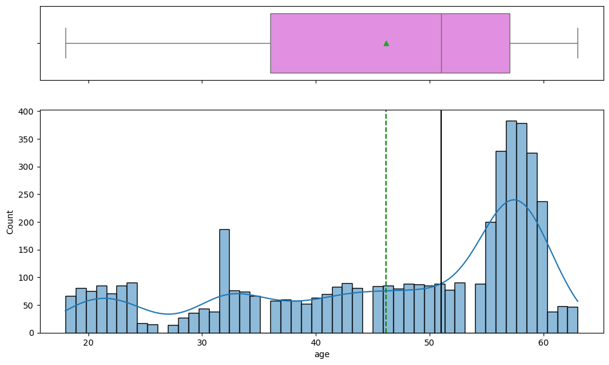

```python
#Check Numerical Variables Distribution#
histogram_boxplot(data, "age")
```

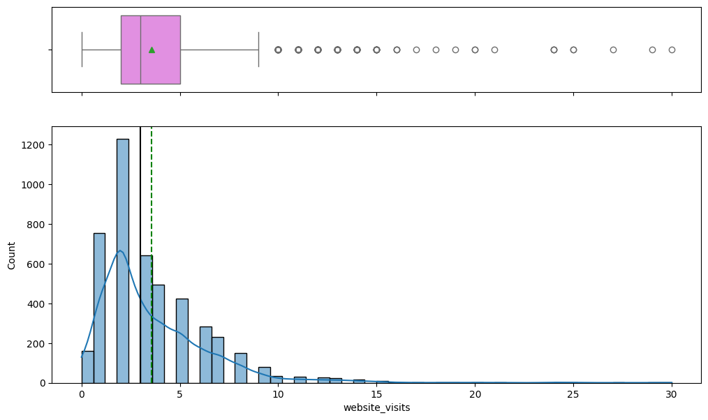

```python
histogram_boxplot(data, "website_visits")
```

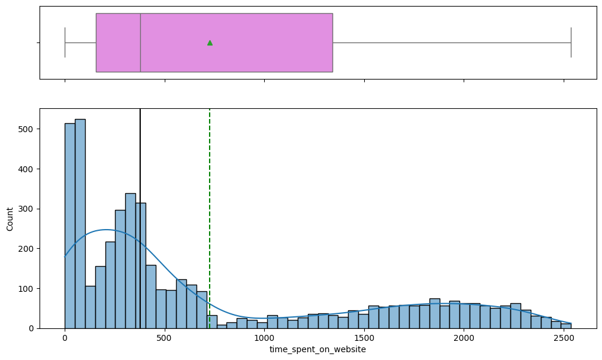

```python
histogram_boxplot(data, "time_spent_on_website")
```

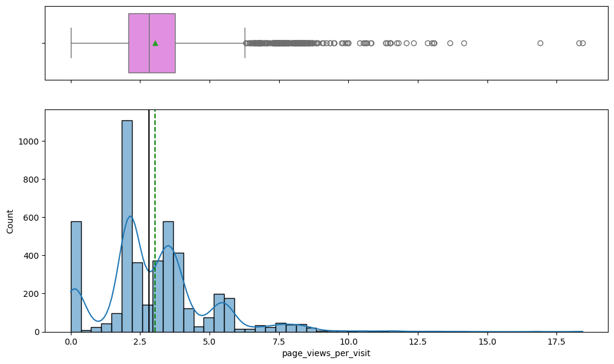

```python
histogram_boxplot(data, "page_views_per_visit")
```

**Bivariate Analysis**

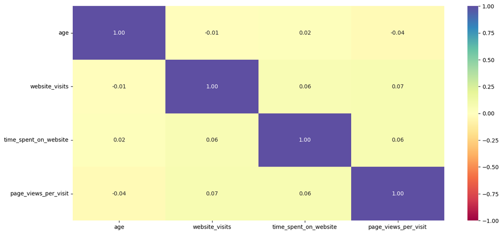

```python
# Exclude non-numeric columns
numeric_data = data.select_dtypes(include=np.number)

# Create heatmap
plt.figure(figsize=(15, 7))
sns.heatmap(numeric_data.corr(), annot=True, vmin=-1, vmax=1, fmt=".2f", cmap="Spectral")
plt.show()
```

Observations:

The heatmap shows that there is no correlation between variables. Which indicates that the categorical variables might be more important for the prediction.

```python
#Perform ANOVA analysis age#
from scipy.stats import f_oneway

categories = data['status'].unique()
grouped_data = [data[data['status'] == cat]['age'] for cat in categories]

# Perform ANOVA
f_stat, p_value = f_oneway(*grouped_data)
print(f"F-statistic: {f_stat}, p-value: {p_value}")
```

```
F-statistic: 70.14722018839548, p-value: 7.22796487160423e-17
```

The F-statistic is quite high (70.15), indicating that the variation in the means of the numerical variable across the different categories of the categorical variable is substantial.

The p-value (7.23e-17) is extremely small, far below the common significance threshold of 0.05. This means that the likelihood of observing such a difference in means purely by chance is almost negligible.

These results provide strong evidence that the status significantly influences the age, suggesting that different categories have different average values for the numerical variable.

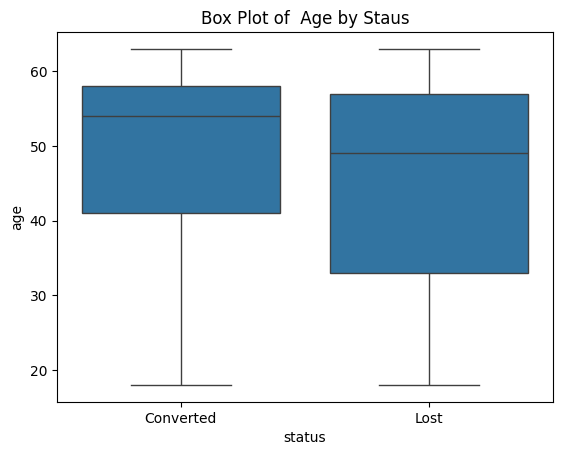

```python
# Create a box plot
sns.boxplot(x='status', y='age', data=data)

# Show the plot
plt.title("Box Plot of  Age by Staus")
plt.show()
```

```python
#Perform ANOVA analysis website_visits#
from scipy.stats import f_oneway

categories = data['status'].unique()
grouped_data = [data[data['status'] == cat]['website_visits'] for cat in categories]

# Perform ANOVA
f_stat, p_value = f_oneway(*grouped_data)
print(f"F-statistic: {f_stat}, p-value: {p_value}")
```

```
F-statistic: 0.28998545940447984, p-value: 0.5902559272197323
```

There is no significant relationship between the status and the website_visits variable.

```python
#Perform ANOVA analysis time_spent_on_website#
from scipy.stats import f_oneway

categories = data['status'].unique()
grouped_data = [data[data['status'] == cat]['time_spent_on_website'] for cat in categories]

# Perform ANOVA
f_stat, p_value = f_oneway(*grouped_data)
print(f"F-statistic: {f_stat}, p-value: {p_value}")
```

```
F-statistic: 460.729124296937, p-value: 1.7649772195552433e-97
```

[figure not shown]

```python
# Create a box plot
sns.boxplot(x='status', y='time_spent_on_website', data=data)

# Show the plot
plt.title("Box Plot of  Age by Staus")
plt.show()
```

The F-statistic is quite high (460), indicating that the variation in the means of the numerical variable across the different categories of the categorical variable is substantial.

The p-value (1.7649772195552433e-97) is extremely small, far below the common significance threshold of 0.05. This means that the likelihood of observing such a difference in means purely by chance is almost negligible.

These results provide strong evidence that the status significantly influences the time_spent_on_website. The more the users spent time on the website, the more is the change to the lead of being converted

```python
#Perform ANOVA analysis page_views_per_visit#
from scipy.stats import f_oneway

categories = data['status'].unique()
grouped_data = [data[data['status'] == cat]['page_views_per_visit'] for cat in categories]

# Perform ANOVA
f_stat, p_value = f_oneway(*grouped_data)
print(f"F-statistic: {f_stat}, p-value: {p_value}")
```

```
F-statistic: 0.007679376031340959, p-value: 0.9301729463874393
```

There is no significant relationship between the status and the page_views_per_vist variable.